# 2.ETS

```python
import datetime
principio = datetime.datetime.now()
```

```python
import warnings
warnings.filterwarnings('ignore')
# version 2.03
```

```python
# Packages
import pandas as pd
import numpy as np
import matplotlib.pyplot as plt
```

[output not shown]

```python
# Read Data
data = pd.read_csv('../data/datos sin días.csv')
data.set_index('Fecha', inplace=True)
```

```python
data['Billetes'] = data['Billetes'].astype('float64')
data.index = pd.to_datetime(data['Billetes'].index)
data['Billetes'].astype('float64').to_period('D')
```

```
Fecha
2013-01-01     2338.0
2013-01-02     9376.0
2013-01-03     9190.0
2013-01-04     9523.0
2013-01-05     5492.0
               ...
2016-12-27    23928.0
2016-12-28    23960.0
2016-12-29    24279.0
2016-12-30    22763.0
2016-12-31     5346.0
Freq: D, Name: Billetes, Length: 1461, dtype: float64
```

### Gráfico de ingresos

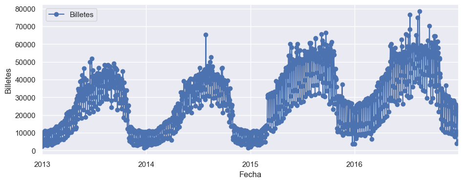

```python
import seaborn as sns
# Use seaborn style defaults and set the default figure size
sns.set(rc={'figure.figsize':(11, 4)})
ax = data.plot(marker='o', linestyle='-')
ax.set_ylabel('Billetes');
```

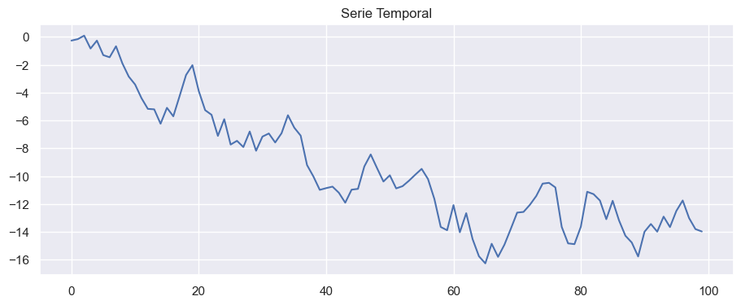

```
Estadística ADF: -1.9298887321528755
Valor p: 0.3181337441667048
Valores críticos: {'1%': -3.498198082189098, '5%': -2.891208211860468, '10%': -2.5825959973472097}
La serie no es estacionaria en varianza (no se puede rechazar la hipótesis nula)
```

```python
import pandas as pd
import numpy as np
import matplotlib.pyplot as plt
from statsmodels.tsa.stattools import adfuller

# Generar una serie temporal ficticia (puedes reemplazarla con tus propios datos)
np.random.seed(41)
serie_temporal = np.cumsum(np.random.normal(size=100))

# Función para realizar la prueba de Dickey-Fuller Aumentada
def prueba_adf(data):
    resultado_adf = adfuller(data, autolag='AIC')
    print('Estadística ADF:', resultado_adf[0])
    print('Valor p:', resultado_adf[1])
    print('Valores críticos:', resultado_adf[4])

    if resultado_adf[1] <= 0.05:
        print("La serie es estacionaria en varianza (rechazar la hipótesis nula)")
    else:
        print("La serie no es estacionaria en varianza (no se puede rechazar la hipótesis nula)")

# Visualizar la serie temporal
plt.plot(serie_temporal)
plt.title('Serie Temporal')
plt.show()

# Realizar la prueba de Dickey-Fuller Aumentada
prueba_adf(serie_temporal)
```

```python
from sktime.forecasting.base import ForecastingHorizon
from sktime.utils.plotting import plot_series
from sktime.forecasting.model_selection import temporal_train_test_split
```

```python
y = data['Billetes'].astype('float64').to_period('d')
```

```python
y_train, y_test = temporal_train_test_split(y, test_size=31)
```

```
1430 31
```

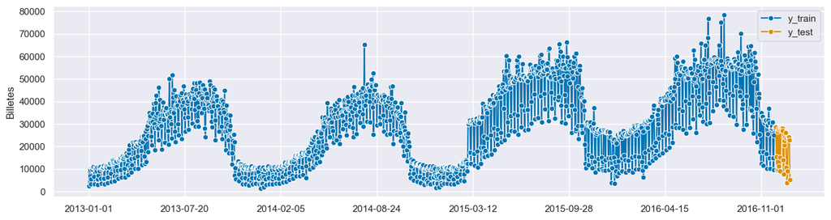

```python
plot_series(y_train, y_test, labels=["y_train", "y_test"])
print(y_train.shape[0], y_test.shape[0])
```

Aquí, utilizamos como test el último mes. Durante la elaboración del trabajo consideré la posibilidad de probar como test también enero de 2016 para comprobar cómo se comportaba la serie en el mes en cuestión, ya que cada uno tiene sus propios festivos y no he colocado una variable dummy para ellos en esta serie temporal.

```python
from sktime.forecasting.ets import AutoETS
```

```python
fh = np.arange(1, 32)
```

Tras utilizar un bucle for en el que hemos probado las distintas combinaciones de parámetros para elaborar el AutoETS, nos hemos quedado con un error de tipo adivico, una tendencia multiplicativa y una estacionalidad aditiva. Además, esta estacionalidad es de 7 días. Esto quiere decir que, cuando miramos datos diarios, **la mayor estacionalidad que se produce es semanal**.

```python
data_auto_model = AutoETS(
        error="additive",
        trend="multiplicative",
        seasonal="additive",
        sp=7,
        n_jobs=-1
    )
```

```python
data_auto_model.fit(y_train)
```

```
AutoETS(error='additive', n_jobs=-1, seasonal='additive', sp=7,
        trend='multiplicative')
```

```python
print(data_auto_model.summary())
```

```
                                 ETS Results
==============================================================================
Dep. Variable:               Billetes   No. Observations:                 1430
Model:                       ETS(AMA)   Log Likelihood              -14244.966
Date:                Sun, 07 Jan 2024   AIC                          28515.933
Time:                        19:44:43   BIC                          28584.384
Sample:                    01-01-2013   HQIC                         28541.494
                         - 11-30-2016   Scale                     26301931.972
Covariance Type:               approx
======================================================================================
                         coef    std err          z      P>|z|      [0.025      0.975]
--------------------------------------------------------------------------------------
smoothing_level        0.2377        nan        nan        nan         nan         nan
smoothing_trend        0.0019   3.95e-08   4.83e+04      0.000       0.002       0.002
smoothing_seasonal     0.5136      0.002    318.083      0.000       0.510       0.517
initial_level       7678.0667   1.52e-08   5.05e+11      0.000    7678.067    7678.067
initial_trend          0.7399      0.000   5946.276      0.000       0.740       0.740
initial_seasonal.0   685.5714   1.17e-08   5.84e+10      0.000     685.571     685.571
initial_seasonal.1   681.7143   1.08e-08   6.29e+10      0.000     681.714     681.714
initial_seasonal.2   432.7857   9.67e-09   4.48e+10      0.000     432.786     432.786
initial_seasonal.3  1486.2786   9.29e-09    1.6e+11      0.000    1486.279    1486.279
initial_seasonal.4 -3595.3929   9.13e-09  -3.94e+11      0.000   -3595.393   -3595.393
initial_seasonal.5 -6206.5714   8.98e-09  -6.91e+11      0.000   -6206.571   -6206.571
initial_seasonal.6          0   8.29e-09          0      1.000   -1.63e-08    1.63e-08
===================================================================================
Ljung-Box (Q):                      131.51   Jarque-Bera (JB):              1808.38
Prob(Q):                              0.00   Prob(JB):                         0.00
Heteroskedasticity (H):               2.92   Skew:                            -0.60
Prob(H) (two-sided):                  0.00   Kurtosis:                         8.38
===================================================================================

Warnings:
[1] Covariance matrix calculated using numerical (complex-step) differentiation.
[2] Covariance matrix is singular or near-singular, with condition number 1.77e+27. Standard errors may be unstable.
```

```python
# step 5: querying predictions
data_pred = data_auto_model.predict(fh)
```

```python
#Intervalo de confianza
data_pred_ints = data_auto_model.predict_interval(fh, coverage=0.9)
data_pred_ints
```

|  | Coverage 0.9 lower | Coverage 0.9 upper |
| --- | --- | --- |
| 2016-12-01 | 21328.558069 | 38014.037327 |
| 2016-12-02 | 20668.412545 | 38428.494379 |
| 2016-12-03 | 4280.666718 | 22907.264004 |
| 2016-12-04 | -997.314343 | 17062.725079 |
| 2016-12-05 | 14819.284374 | 33730.245734 |
| 2016-12-06 | 16273.052330 | 35573.425291 |
| 2016-12-07 | 16632.585421 | 35894.570055 |
| 2016-12-08 | 16893.137284 | 40072.261338 |
| 2016-12-09 | 15894.670197 | 39422.871049 |
| 2016-12-10 | -906.079517 | 23438.391215 |
| 2016-12-11 | -7088.332784 | 18413.119283 |
| 2016-12-12 | 10129.543359 | 34885.648607 |
| 2016-12-13 | 10809.339952 | 36924.898507 |
| 2016-12-14 | 9804.572045 | 37506.159116 |
| 2016-12-15 | 11659.491469 | 40911.835236 |
| 2016-12-16 | 11179.698632 | 40312.329819 |
| 2016-12-17 | -5772.074185 | 24297.101189 |
| 2016-12-18 | -11797.017681 | 19246.038417 |
| 2016-12-19 | 4580.342047 | 36278.334103 |
| 2016-12-20 | 6015.435196 | 38840.620454 |
| 2016-12-21 | 5907.172029 | 38152.167896 |
| 2016-12-22 | 6356.497891 | 41696.283338 |
| 2016-12-23 | 5642.009784 | 41232.663641 |
| 2016-12-24 | -9700.397462 | 26309.797379 |
| 2016-12-25 | -16201.121650 | 19868.311867 |
| 2016-12-26 | 237.140165 | 36228.957058 |
| 2016-12-27 | 794.754692 | 37357.704582 |
| 2016-12-28 | 739.692746 | 37853.800146 |
| 2016-12-29 | 2461.901283 | 42769.004744 |
| 2016-12-30 | 903.368044 | 40818.318283 |
| 2016-12-31 | -16259.506327 | 26088.044681 |

```
(<Figure size 1600x400 with 1 Axes>, <AxesSubplot:ylabel='Billetes'>)
```

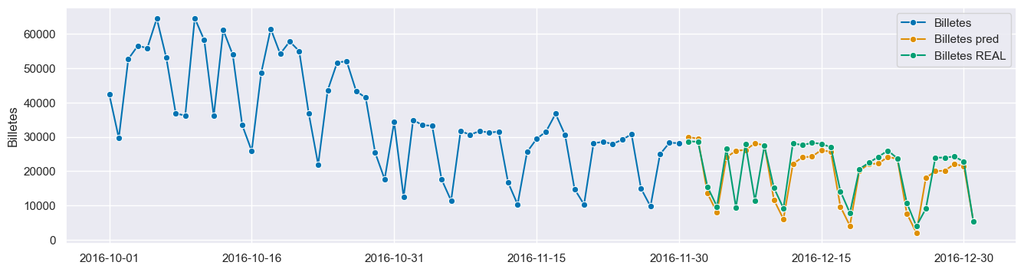

```python
# optional: plotting predictions and past data
plot_series(y_train["2016-10":], data_pred,y_test, labels=["Billetes", "Billetes pred", "Billetes REAL"])
```

El modelo predicho replica muy bien el comportamiento de la serie en la fase de test. Sin embargo, hay dos días que no detecta: el 6 y el 8 de diciembre, que son festivos. Probablemente, con más tiempo para realizar este trabajo, podríamos haber establecido una variable dummy que avisase de cada festivo.

```python
print(data_pred_ints.keys())
```

```
MultiIndex([('Coverage', 0.9, 'lower'),
            ('Coverage', 0.9, 'upper')],
           )
```

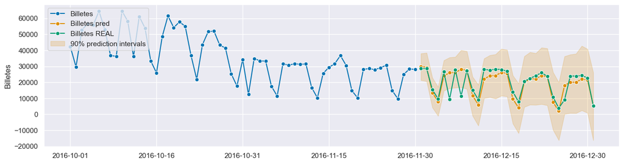

```python
fig, ax = plot_series(y_train["2016-10":], data_pred, y_test, labels=["Billetes", "Billetes pred", "Billetes REAL"])
ax.fill_between(
    ax.get_lines()[-2].get_xdata(),
    data_pred_ints[('Coverage', 0.9, 'lower')],
    data_pred_ints[('Coverage', 0.9, 'upper')],
    alpha=0.2,
    color=ax.get_lines()[-2].get_c(),
    label=f"90% prediction intervals",
)
ax.legend(loc='upper left')
```

Estos errores del puente de la Constitución son los únicos días que se salen del intervalo de confianza de 0.9.

```
(<Figure size 1600x400 with 1 Axes>, <AxesSubplot:ylabel='Billetes'>)
```

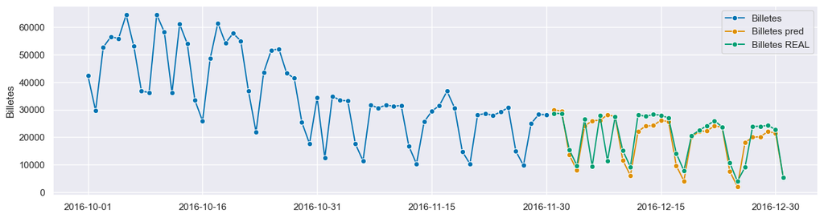

```python
plot_series(y_train["2016-10":], data_pred,y_test, labels=["Billetes", "Billetes pred", "Billetes REAL"])
```

## Comprobaciones del error

```python
from sktime.performance_metrics.forecasting import mean_absolute_percentage_error
from sktime.performance_metrics.forecasting import MeanSquaredError
from sklearn.metrics import r2_score

mape = mean_absolute_percentage_error(y_test[0:31], data_pred[0:31])
mse = MeanSquaredError()
mse = mse(y_test[0:31], data_pred[0:31])
r2 = r2_score(list(y_test[0:31]), list(data_pred[0:31]))

print(f'MAPE: {mape}')
print(f'MSE: {mse}')
print(f'R2 Score: {r2}')
```

```
MAPE: 0.2646999682186132
MSE: 27020314.698644344
R2 Score: 0.5927001089375472
```

Para medir la precisión de este modelo comprobamos el MAPE, el MSE y el R2 score.

Para elegir modelo nos hemos centrado en el MAPE, que es el que proporciona una medida relativa de la precisión de un modelo de pronóstico al evaluar el porcentaje promedio de error entre las predicciones y los valores reales.

El MSE, que es la suma de los cuadrados de los errores dividido entre el número total de observaciones, penaliza fuertemente los errores de mayor calado.

Con R2 conseguimos saber cuánto de bien explica el modelo la variabilidad total de los datos. Su interpretación varía entre 0 y 1, y un valor más alto indica un mejor ajuste del modelo.

## Predicción

```python
# step 2: specifying forecasting horizon
fh = np.arange(1, 32)

# step 3: specifying the forecasting algorithm
bus_auto_model = AutoETS(
        error="additive",
        trend="multiplicative",
        seasonal="additive",
        sp=7,
        n_jobs=-1
    )
```

```python
bus_auto_model.fit(y)
```

```
AutoETS(error='additive', n_jobs=-1, seasonal='additive', sp=7,
        trend='multiplicative')
```

```python
np.arange(0, 31)
```

```
array([ 0,  1,  2,  3,  4,  5,  6,  7,  8,  9, 10, 11, 12, 13, 14, 15, 16,
       17, 18, 19, 20, 21, 22, 23, 24, 25, 26, 27, 28, 29, 30])
```

```python
print(bus_auto_model.summary())
```

```
                                 ETS Results
==============================================================================
Dep. Variable:               Billetes   No. Observations:                 1461
Model:                       ETS(AMA)   Log Likelihood              -14643.185
Date:                Sun, 07 Jan 2024   AIC                          29312.369
Time:                        19:44:44   BIC                          29381.099
Sample:                    01-01-2013   HQIC                         29338.007
                         - 12-31-2016   Scale                     29726522.801
Covariance Type:               approx
======================================================================================
                         coef    std err          z      P>|z|      [0.025      0.975]
--------------------------------------------------------------------------------------
smoothing_level        0.3293   2.58e-09   1.28e+08      0.000       0.329       0.329
smoothing_trend     3.293e-05        nan        nan        nan         nan         nan
smoothing_seasonal     0.6269        nan        nan        nan         nan         nan
initial_level       7678.0667        nan        nan        nan         nan         nan
initial_trend          0.9764        nan        nan        nan         nan         nan
initial_seasonal.0   685.5714        nan        nan        nan         nan         nan
initial_seasonal.1   681.7143        nan        nan        nan         nan         nan
initial_seasonal.2   432.7857        nan        nan        nan         nan         nan
initial_seasonal.3  1486.2786      0.108   1.38e+04      0.000    1486.067    1486.490
initial_seasonal.4 -3595.3929      0.015  -2.37e+05      0.000   -3595.423   -3595.363
initial_seasonal.5 -6206.5714        nan        nan        nan         nan         nan
initial_seasonal.6          0        nan        nan        nan         nan         nan
===================================================================================
Ljung-Box (Q):                      259.67   Jarque-Bera (JB):              1226.00
Prob(Q):                              0.00   Prob(JB):                         0.00
Heteroskedasticity (H):               3.01   Skew:                            -0.32
Prob(H) (two-sided):                  0.00   Kurtosis:                         7.44
===================================================================================

Warnings:
[1] Covariance matrix calculated using numerical (complex-step) differentiation.
[2] Covariance matrix is singular or near-singular, with condition number 4.4e+14. Standard errors may be unstable.
```

```python
y_pred = bus_auto_model.predict(fh)
y_pred
```

```
2017-01-01     3229.429779
2017-01-02    12826.602807
2017-01-03    24928.925736
2017-01-04    24482.035512
2017-01-05    24341.022030
2017-01-06    22647.030542
2017-01-07     7177.431710
2017-01-08     4812.315272
2017-01-09    14386.657916
2017-01-10    26466.479750
2017-01-11    25997.412970
2017-01-12    25834.542792
2017-01-13    24119.009851
2017-01-14     8628.180265
2017-01-15     6242.139290
2017-01-16    15795.859198
2017-01-17    27855.355742
2017-01-18    27366.256830
2017-01-19    27183.643448
2017-01-20    25448.652066
2017-01-21     9938.644693
2017-01-22     7533.702536
2017-01-23    17068.793879
2017-01-24    29109.930544
2017-01-25    28602.736562
2017-01-26    28402.289100
2017-01-27    26649.720863
2017-01-28    11122.390152
2017-01-29     8700.374516
2017-01-30    18218.638635
2017-01-31    30243.190779
Freq: D, dtype: float64
```

```python
bus_pred_ints = bus_auto_model.predict_interval(fh, coverage=0.9)
```

```
(<Figure size 1600x400 with 1 Axes>, <AxesSubplot:ylabel='Billetes'>)
```

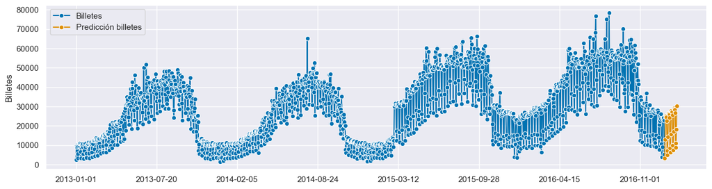

```python
plot_series(y, y_pred, labels=["Billetes", "Predicción billetes"])
```

```
(<Figure size 1600x400 with 1 Axes>, <AxesSubplot:ylabel='Billetes'>)
```

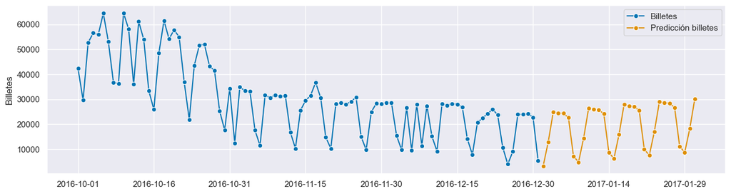

```python
plot_series(y["2016-10":], y_pred, labels=["Billetes", "Predicción billetes"])
```

```python
y
```

```
2013-01-01     2338.0
2013-01-02     9376.0
2013-01-03     9190.0
2013-01-04     9523.0
2013-01-05     5492.0
               ...
2016-12-27    23928.0
2016-12-28    23960.0
2016-12-29    24279.0
2016-12-30    22763.0
2016-12-31     5346.0
Freq: D, Name: Billetes, Length: 1461, dtype: float64
```

```python
print(bus_pred_ints.keys())
```

```
MultiIndex([('Coverage', 0.9, 'lower'),
            ('Coverage', 0.9, 'upper')],
           )
```

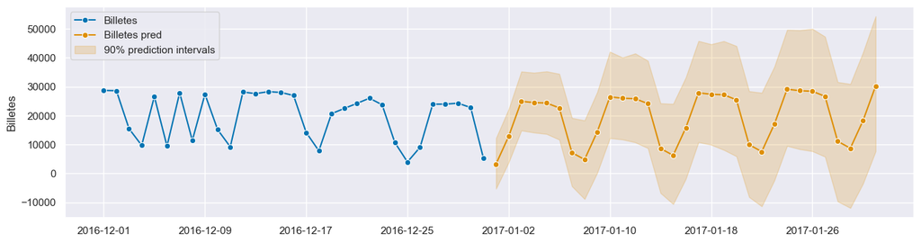

```python
fig, ax = plot_series(y_test, y_pred, labels=["Billetes", "Billetes pred"])
ax.fill_between(
    ax.get_lines()[-1].get_xdata(),
    bus_pred_ints[('Coverage', 0.9, 'lower')],
    bus_pred_ints[('Coverage', 0.9, 'upper')],
    alpha=0.2,
    color=ax.get_lines()[-1].get_c(),
    label=f"90% prediction intervals",
)
ax.legend(loc='upper left')
```

Aquí la predicción de la serie temporal con los intervalos de confianza. Como se puede ver, y hemos comentado a la hora de establecer la periodicidad estacional, esta, donde más se observa, es en las semanas. Los sábados y los domingos, el uso del transporte público cae drásticamente.

## Pasarlo a csv

```python
y_pred.to_csv('../data/resultados diarios.csv', index=False, float_format='%.0f')
```

```python
final = datetime.datetime.now()
duracion = final-principio
print(duracion)
```

```
0:00:04.640195
```